# Replacing academic journals

## Replacing academic journals

with repositories and peer communities

**Pandelis Perakakis** · pperakakis@ucm.es  
BrainHack Donostia, 4 November 2026

[figure not shown]

# A solution to a problem we no longer have

## 1665: the journal is invented

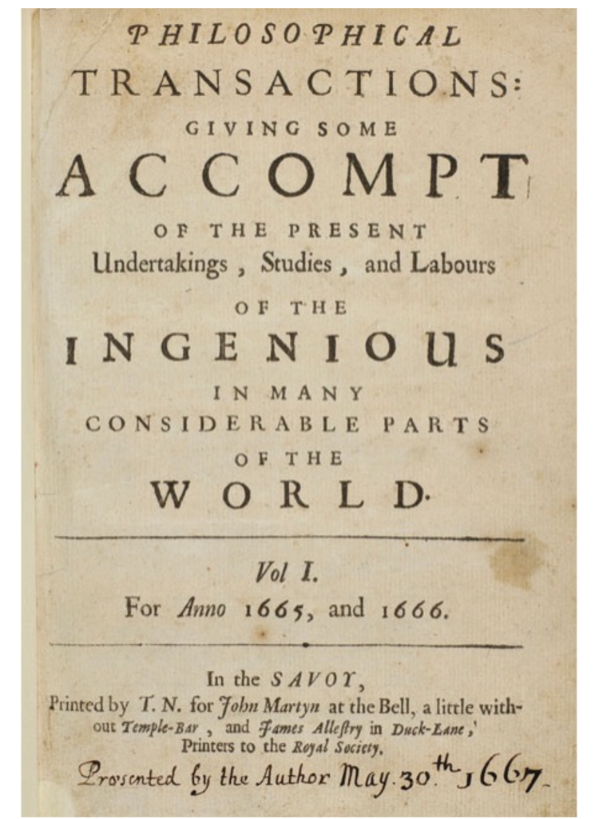

*Philosophical Transactions* solved two problems of its time: **registering** who found what first, and **distributing** findings to scholars in other cities, on paper.

The web solved both.

## Peer review came much later

[figure not shown]

Einstein to the editor of *Physical Review*, 1936, after his paper was sent to a referee without his consent.

## Three fundamental processes in science

|  | All three controlled by journals |
| --- | --- |
| Validation | 2–3 anonymous reviewersreviews not available |
| Evaluation | The impact factor and the journal's prestigestand in for the quality of the work |
| Dissemination | Private serversrestrictive licences, subscriptions or APCs |

# Validation

2–3 anonymous reviewers; reviews not available

## Does peer review work?

[figure not shown]

[figure not shown]

Smith, *Times Higher Education*, 2015 · Jefferson et al., *JAMA* 287:2784, 2002 · Jefferson et al., Cochrane Review, 2007

## Reviewers agree little more than chance

[figure not shown]

Rothwell & Martyn (2000). *Brain* 123:1964–1969

## Retractions

[figure not shown]

Van Noorden (2011). *Nature* 478:26–28

## The reviewing is done by us, unpaid

In 2020 researchers spent **more than 100 million hours** on peer review: over 15,000 years of work. The time of US reviewers alone was worth more than US$1.5 billion.

Aczel, Szaszi & Holcombe (2021). *Research Integrity and Peer Review* 6:14

# Evaluation

The impact factor and the journal’s prestige stand in for the quality of the work

## A number for sale

[figure not shown]

1958 · Institute for Scientific Information founded  
1992 · bought by Thomson for **US$210 million**  
2016 · sold to private equity, now Clarivate, for **US$3.55 billion**

> “Journal impact factors are only used, and with caution, to measure and compare the influence of entire journals, but not for the assessment of single papers, and certainly not for the assessment of researchers.”

Garfield (2006). *JAMA* 295:90–93

## A journal oligopoly

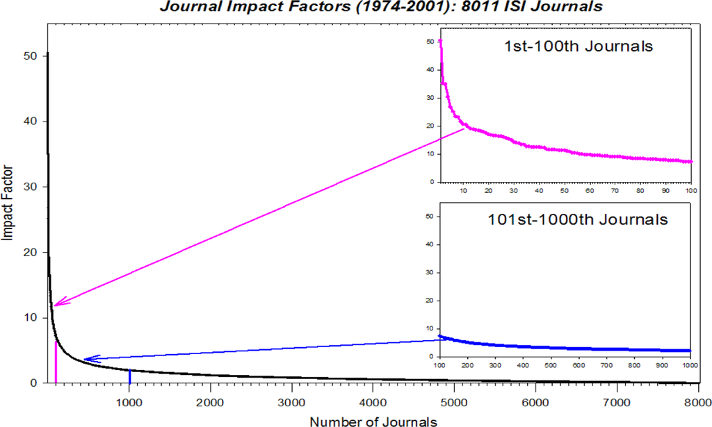

Impact factors of 8,011 ISI journals, 1974–2001 · Taylor, Perakakis & Trachana (2008). The siege of science. *Ethics in Science and Environmental Politics* 8:17–40

## The impact factor is not yours

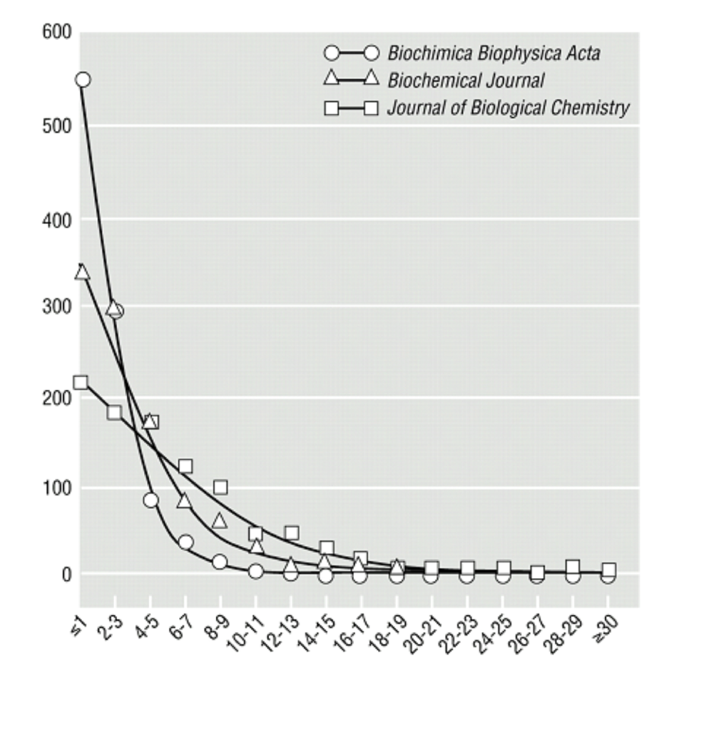

Articles by citations received in a year, three biochemistry journals · Seglen (1997). *BMJ* 314:497, reproduced in Taylor, Perakakis & Trachana (2008)

## High impact, not higher standards

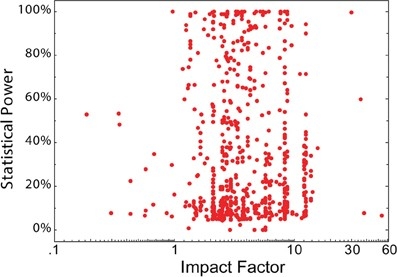

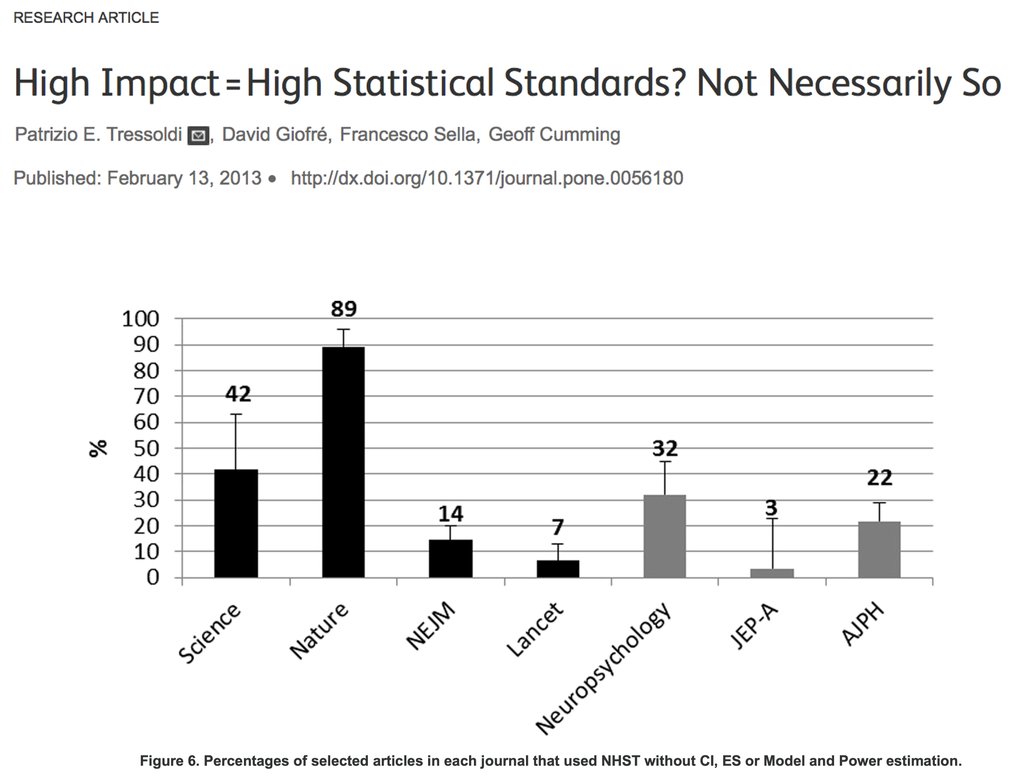

Statistical power against impact factor: Brembs, Button & Munafò (2013). *Frontiers in Human Neuroscience* 7:291 · Tressoldi et al. (2013). *PLOS ONE* 8:e56180

## Scientists, or academics?

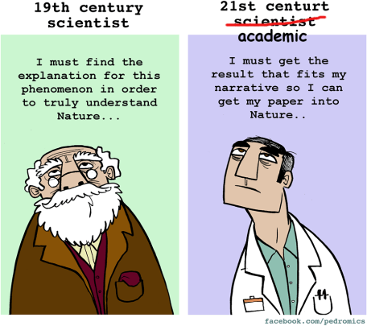

> “Most researchers today, especially those at the beginning of their careers, want to be scientists, but are forced to become academics.”

Perakakis (2017). Open scientists in the shoes of frustrated academics. *Euroscientist*

# Dissemination

Private servers, restrictive licences, subscriptions or APCs

## What two Spanish universities pay for subscriptions

|  | 2020 | 2024 |
| --- | --- | --- |
| Universidad Complutense de Madrid | 2,846,040.62 € | 2,972,520.85 € |
| Universidad de Granada | 1,045,250.00 € | 2,250,000.00 € |

Budgets for journal subscriptions · [ucm.es/portaldetransparencia](https://ucm.es/portaldetransparencia/informacionpresupuestaria) · [gerencia.ugr.es](https://gerencia.ugr.es/pages/vger_eco/presupuestos/presupuesto2020ugr)

## The bill keeps rising

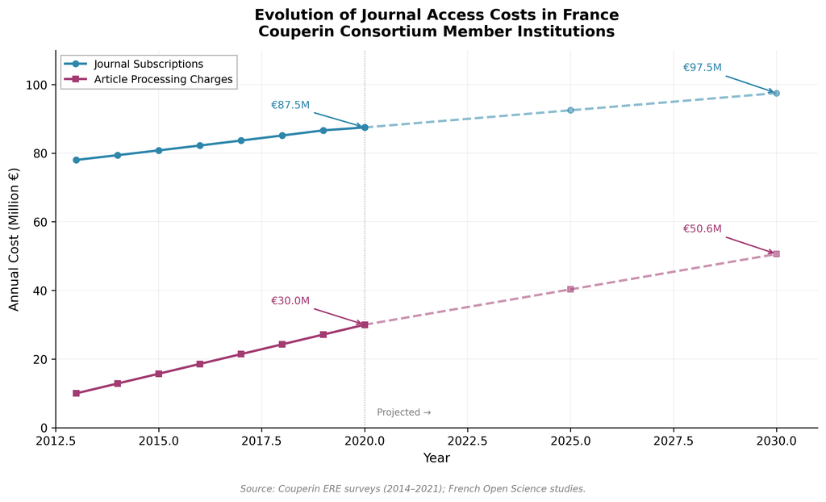

Couperin consortium, France: subscriptions and APCs, 2013–2030

## What we pay for an article, and what it costs

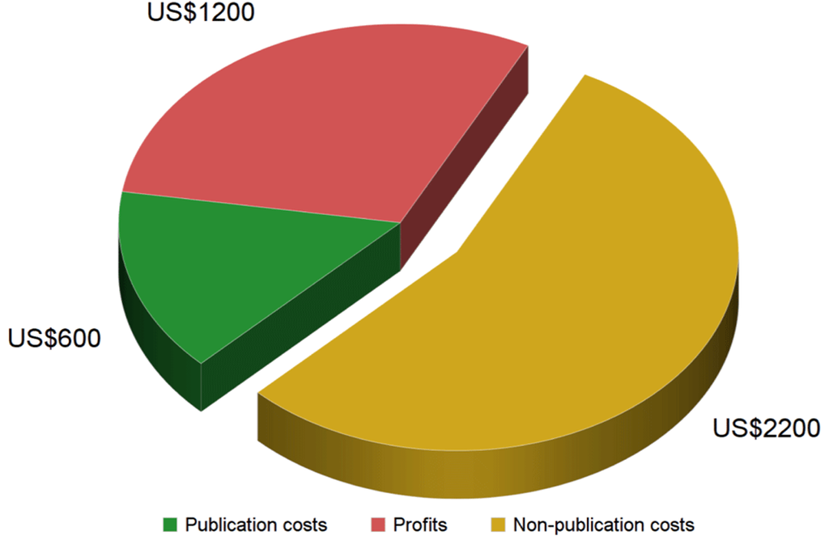

Grossmann & Brembs (2021). Current market rates for scholarly publishing services. *F1000Research* 10:20

## Open access: from a right to a business

[figure not shown]

Free availability on the public internet, to read, download, copy, distribute, print, search or link to the full texts, without financial, legal or technical barriers.

Two complementary strategies: **self-archiving** in repositories (green) and **open access journals**.

> “Gold OA represents a business opportunity, whereas Green OA represents a business problem.”

Joseph Esposito, publishing consultant, *The Scholarly Kitchen*, 2013 · budapestopenaccessinitiative.org

## Transformative agreements: a service for the authors!

[figure not shown]

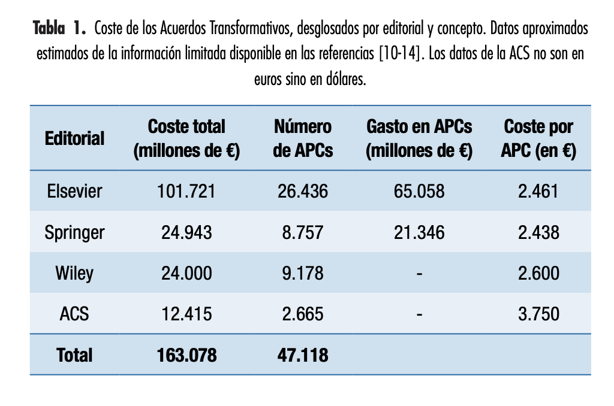

UCM library guide to the CRUE–CSIC agreements · González MacDowell (2023). El verdadero coste de los acuerdos transformativos. *Anales de Química*

# A business, not a service

## Profit margins, 2007/2008

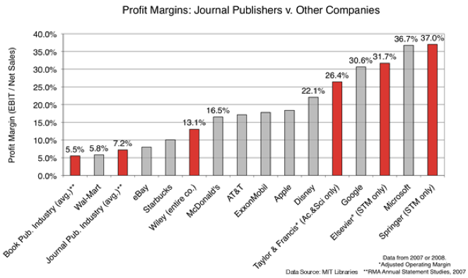

MIT Libraries; RMA Annual Statement Studies, 2007 (data from 2007 or 2008)

## Profit margins, 2024

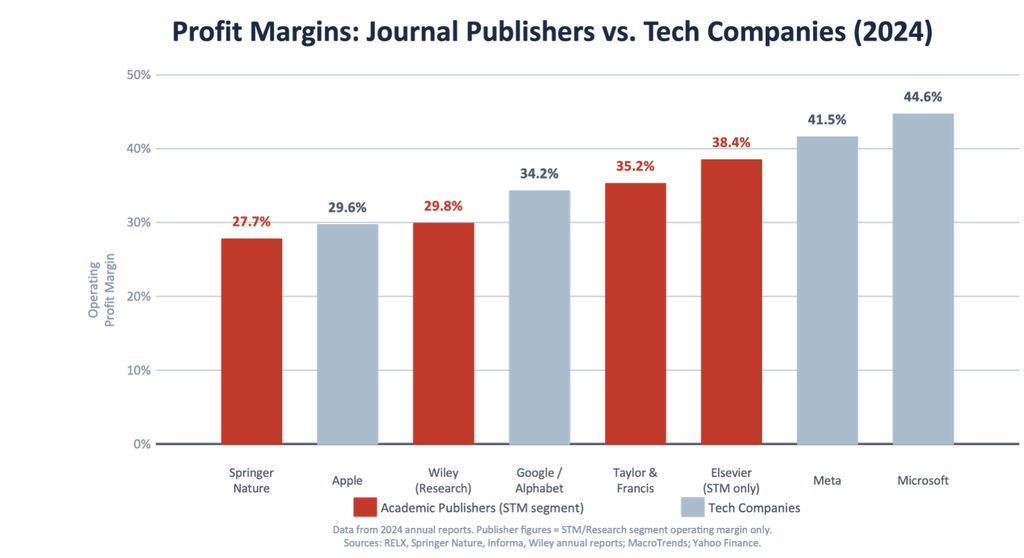

Company annual reports, 2024 (STM segments for publishers)

| 2012 | Elsevier | Pure | research information system |
| --- | --- | --- | --- |
| 2013 | Elsevier | Mendeley | reference manager |
| 2016 | Elsevier | SSRN | preprint server |
| 2016 | Wiley | Atypon | publishing platform, US$120 million |
| 2017 | Elsevier | bepress | repository software |
| 2017 | Elsevier | Plum Analytics | altmetrics |
| 2017 | Clarivate | Publons | records of peer review |
| 2018 | Elsevier | Aries Systems | Editorial Manager |
| 2018 | Clarivate | Kopernio | access to papers |
| 2020 | Taylor & Francis | F1000 Research | open publishing platform |
| 2021 | Wiley | Hindawi | open access publisher, US$298 million |
| 2021 | Clarivate | ProQuest | US$5.3 billion |
| 2022 | Elsevier | Interfolio | faculty evaluation |
| 2022 | Springer Nature | Research Square | preprint server |

Company press releases and SEC filings; Library Technology Guides, mergers timeline

# The tools for the revolution are here

## The infrastructure has existed since 1991

[figure not shown]

Tim Berners-Lee and the World Wide Web · Paul Ginsparg and arXiv

## Repositories everywhere

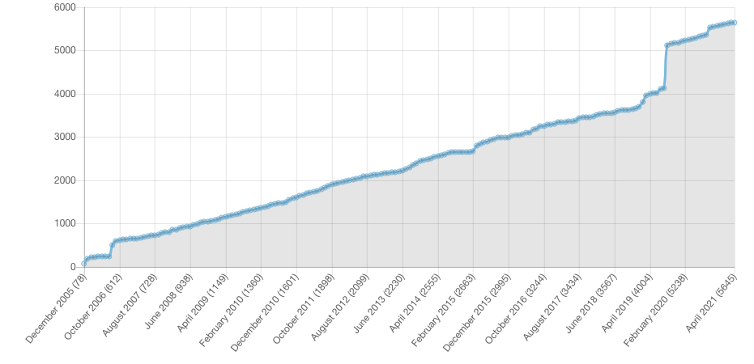

OpenDOAR, number of open access repositories · [v2.sherpa.ac.uk](https://v2.sherpa.ac.uk/view/repository_visualisations/1.html)

## Our model unchanged since 2010

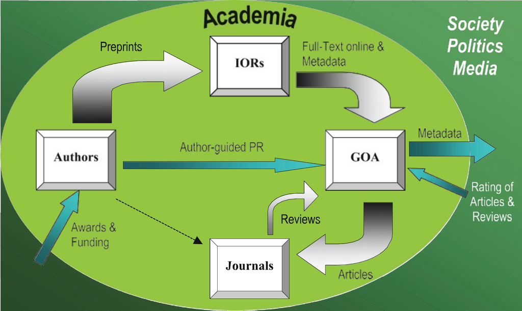

Perakakis, Taylor & Trachana (2010). Natural selection of academic papers. *Scientometrics* 85:553–559

## Replacing academic journals

[figure not shown]

A federated network of interoperable research objects, governed by the scholarly community and connected by open standards.

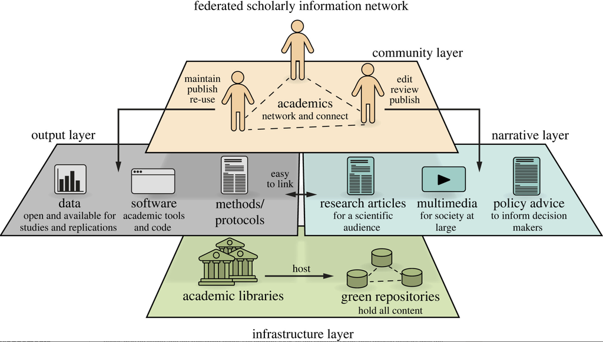

Brembs et al. (2023). Replacing academic journals. *Royal Society Open Science* 10:230206

## The three processes decoupled

|  | Each done by those who should do it |
| --- | --- |
| Validation | Peer communitiesopen reviews, published and citable: PCI, scientific societies |
| Evaluation | Assessment of the work itself, not of the journal's nameDORA, CoARA, funders and evaluation committees |
| Dissemination | Repositoriespublic, open, permanent: institutional repositories, Zenodo, arXiv, PsyArXiv |

## Peer communities review preprints

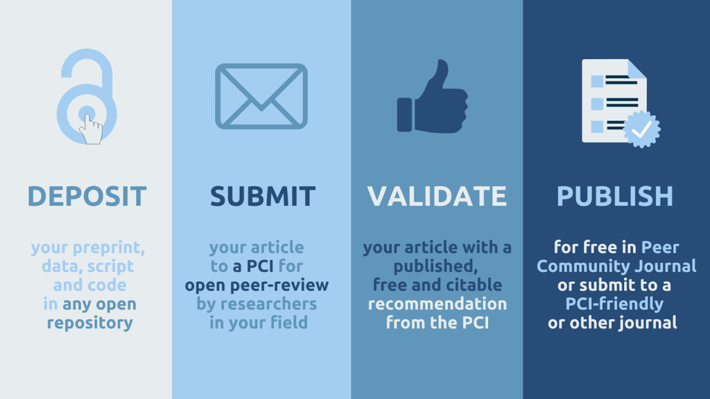

Peer Community In · peercommunityin.org

## Repositories and review services talk to each other

[figure not shown]

With COAR Notify, a reviewer’s report travels back to the repository and is shown next to the preprint.

coar-repositories.org/notify

# Psicológica: a journal without a publisher

## 2022: a society journal moves into a public repository

[figure not shown]

[figure not shown]

psicologicajournal.com · digital.csic.es/handle/10261/228593

## About €30 an article

[figure not shown]

> “At an estimated cost of €30 (US$34) per publication, Psicológica can increase its output without incurring substantial extra costs.”

Bernal & Perakakis (2023). *Nature* 619:698

## The three jobs, at Psicológica

|  | Collaboration of academics and librarians |
| --- | --- |
| Validation | The society's editors and reviewersreviews deposited next to the article, each with its own identifier |
| Evaluation | The open recordpreprint, reviews, comments and the published article, all readable and citable |
| Dissemination | DIGITAL.CSICthe public repository of the Spanish National Research Council; no publisher |

Example: an article with its reviews and comments · hdl.handle.net/10261/264625

## Remove the profit, remove the obstacles

Publishers had the money to do all of this and never did. Communities that care for science rather than profit can do it now:

- open reviews as research objects, deposited and citable
- registration, perservation, metadata curation and discoverability in institutional repositories
- certified reproducibility (trust in science) by *reprocheck*, this week at #BrainHackDonostia2026

[figure not shown]

Where do we go from here?

CHAOS OR COMMUNITY?

Martin Luther King, Jr. (1967)

## Thank you

**Pandelis Perakakis** · pperakakis@ucm.es

pandelisperakakis.info · openscholar.info · psicologicajournal.com